# Simulating City Contact Networks

```r
if(F){
load("NDSSL_basic.Rdata")
source("shared_partner_functions.R")
demog<-demog_process2(demog,eldemog2)
eldemog2<-eldemog_process(eldemog2)
library(sna)
library(parallel)
library(readxl)
library(ergm)
N<-10000
ncores<-10
mode<-"school"
}
```

In previous iterations, we found that simulated annealing can successfully reproduce target mixing matrices consistently, but struggles more on network structure. The first step, then, to provide the annealing algorithm with enough network structure at its starting point. The algorithm can then narrow its scope to look within only those networks that satisfy the structural configuration in the basis network.

We start by producing a basis network that matches the degree distribution of the observed network. We produce a N by N matrix of tie weights corresponding to $d_i * d_j$ where $d$ is the observed degree.

```r
if(F){
#produce network basis with approximate degree distribution
dg<-data.frame(table(unlist(eldemog2[which(eldemog2$mode%in%mode),1:2])))
demogt<-merge(demog,dg,by.x="Person.Id",by.y="Var1",all=T)
demogs<-demogt[sample(1:nrow(demogt),N,replace=T),] #sample nodes
demogs$Freq[is.na(demogs$Freq)]<-0
mat1<-do.call(rbind,lapply(1:N,function(x) demogs$Freq/N))
mat<-(mat1*t(mat1))
mat2<-mat*N/4
net1<-rgraph(N,tprob=mat2,mode="graph")
net1[lower.tri(net1)]<-t(net1[lower.tri(net1)])
net2<-netorig<-as.network(net1,directed=F)
for (x in 2:ncol(demogs)) set.vertex.attribute(net2,names(demogs)[x],demogs[,x])
ks.test(demogs$Freq,degree(net2,gmode="graph"))
}
```

On average, the above code will produce networks that match that degree distribution of the input graph.

Next, we’ll use the annealing algorithm to produce clustering statistcs. We’ll calculate statistics for the number of triangles estimated to be in the network, the edgewise shared partner distribution, and geometrically-weighted edgewise shared partner distribution. These statsitics can all be drawn from an egocentric sample of nodes from a larger network.

```r
if(F){
#calculate number of triangles among your sample
el_obs<-eldemog2[which(eldemog2$mode%in%mode),c(1:2)]
egoids<-demogs$Person.Id#[which(demogs$Freq>0)]
esps<-mclapply(egoids,function(id1){
  subnetegos<-unique(unlist(el_obs[which(el_obs[,1]%in%id1 | el_obs[,2]%in%id1 ),c(1,2)])) #get IDs of all alters of id1
  subnetegos<-subnetegos[subnetegos!=id1] #don't count ego
  if(length(subnetegos)>0){
    subnet_alters<-el_obs[which(el_obs[,1]%in%subnetegos & el_obs[,2]%in%subnetegos ),] #get ties among alters of ego
    sp1<-factor(unlist(subnet_alters),levels=subnetegos)
    esp<-table(unlist(sp1))
    triangles<-nrow(subnet_alters)
    return(list(esp,triangles))
  }

},mc.cores=ncores)
espdist<-table(unlist(lapply(esps,function(x) x[[1]])))/2 #edgewise shared partners
tris<-sum(unlist(lapply(esps,function(x) x[[2]]))) #sum triangles for all nodes
tris<-tris/3 #triangles are counted three times

form<-net2~ #name of the basis network
  triangles

target_stats<-summary(form) #initialize target statistic vector in ergm format
target_stats[1]<-tris #replace target statistic with observed statistic
}
```

These statistics in-hand, we’ll utilize simulated annealing (san) to build a network with the same number of triangles in the observed network while holding the degree distribution constant.

```r
if(F){
for (i in 1:10){ #run san ten times
  newnet<-san(form,target.stats=target_stats,
              only.last = T,
              constraints= ~ edges + degreedist,
              control=list(SAN.tau=10,
                           SAN.maxit=4,
                           SAN.invcov.diag = T,
                           SAN.nsteps = 2^22,
                           parallel=ncores
              ),verbose=T)
  net2<-newnet
}
}
```

Why use only ‘triangles’ and not the more precise ‘edgewise shared partner distribution’? It works better in practice to reduce the number of statistics san focuses on for optimization. Here, we only optimize on triangles and determine whether it is ‘good enough’ to approximate the shared partner distribution.

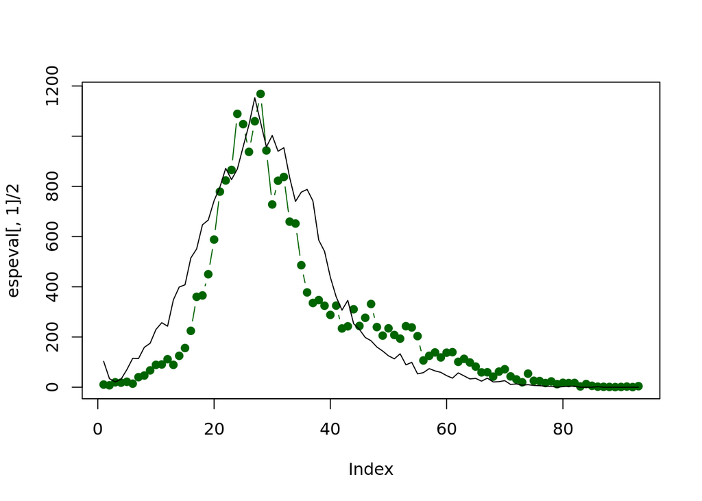

```r
if(F){
#evaluate all other aspects of the network
finform<-net2~ #name of the basis network
  edges+ #total # edges in the network
  degree(0:max(demogs$Freq)) + #degree distribution from degree 0 to max
  mm("agecat") + #age mixing matrix (matrix sums to 'edges')
  mm("Gender") + #gender mixing matrix (matrix sums to 'edges')
  degree(0,by="agecat") + #degree 0 by age category (participation in mode)
  esp(0:max(as.numeric(names(espdist))))+  #triangles/clustering -- seems to be captured well with edges + degree + trianges
  triangles+
  gwesp(0,fixed=T)

newform<-update(finform,paste0("newnet ~ ."))
newstats<-summary(newform) #get new statistics
espeval<-cbind(espdist,newstats[paste0("esp",names(espdist))])
save(espeval,file="espeval.Rdata")
}

load("espeval.Rdata")
plot(espeval[,1]/2,col="darkgreen",type="b",pch=19)
lines(espeval[,2])
```

Does matching to the number of triangles, along with the degree distribution, sufficient to reproduce the edgewise shared partner distribution in the network? In this case, basically, yes.

We can evaluate these and other statistics to make sure, though. If the edgewise shared partner distribution does not match, we can write more code for san to try to match it exactly. Once we have the degree distribution and number of triangles set, we can much more easily produce other statistics as well, one at a time or all together.